# Report

Gabriel Teotonio

9/28/2020

[figure not shown]

## Introduction

In linear algebra we are concerned about linear equations such as:
$$a_1x_1 + \dots + a_nx_n = b,$$
and their representations through matrices. When we talk about machine learning algorithms, most of them have linear algebra and matrix calculation in its core, e.g. regression when is necessary to find the solution of $Y = X B + \varepsilon$, neural nets needs to execute a number of matrix product operations for each layer considered, and others.
With this in mind I implemented a variety of algorithms to analyze the performance of processing it, in relation to speed. Multiple approaches are considered, including C++ [Armadillo](http://arma.sourceforge.net/docs.html) library and different parallel back-ends. The following R package named **matrixProduct** gathers all the development. The **microbenchmark**, **ggplot2**, and **pryr** packages will help us to measure that performance.

```r
library(matrixProduct)
library(microbenchmark)
library(pryr)
library(ggplot2)
library(readr)
library(dplyr)
library(kableExtra)
```

## Approaches

Here I consider two possible ways: lower-level and parallelism way. So we can build our code in a faster language than R, like C++, try to parallelize the code in R or even both.

### Lower-level way

The initial attempt is to measure the performance of base operators for matrix multiplication in R and C++. We know the command `%*%` in R to execute the multiplication and its optimized implementation throughout the years. We also consider the base matrix multiplication command in C++ library Armadillo `*`. To integrate Armadillo to R, let’s use R package [RcppArmadillo](https://cran.r-project.org/web/packages/RcppArmadillo/index.html). We are going to build some simple functions only for calling the base commands of each library. The integration between C++ and R with Rcpp is seamless and simple to get started (all the code can be found [here](https://github.com/gabrielteotonio/intensive-comp)).

#### Functions

##### Armadillo Base

```r
# R code
ArmaBase <- function(mat_1, mat_2) {

  stopifnot(exists("mat_1"))
  stopifnot(exists("mat_2"))

  val <- ArmaBase(mat_1, mat_2)

  invisible(val)
}

# C++ code
#include <RcppArmadillo.h>
// [[Rcpp::depends(RcppArmadillo)]]

// [[Rcpp::export]]
arma::mat ArmaBase(const arma::mat& mat_1, const arma::mat& mat_2) {
  return mat_1*mat_2;
}
```

##### Armadillo Iterator

```r
# R code
ArmaColumnRow <- function(mat_1, mat_2) {

  stopifnot(exists("mat_1"))
  stopifnot(exists("mat_2"))

  val <- ArmaColumnRow(mat_1, mat_2)

  invisible(val)
}

# C++ code
#include <RcppArmadillo.h>
// [[Rcpp::depends(RcppArmadillo)]]

// [[Rcpp::export]]
arma::mat ArmaColumnRow(const arma::mat& mat_1, const arma::mat& mat_2) {
  int n = mat_1.n_rows, m = mat_2.n_cols;
  arma::mat rmat(n, m);

  for (int i = 0; i < n; i++) {
    for (int j = 0; j < m; j++) {
      rmat(i, j) = accu(mat_1.row(i) * mat_2.col(j));
    }
  }
  return rmat;
}
```

#### Versions

##### No garbage collector

```r
trials <- 10000
mat_size <- 3

for (i in 1:trials) {

   mat_1 <- list(matrix(runif(100, 0, 1), 10, 10),
                 matrix(runif(10000, 0, 1), 100, 100),
                 matrix(runif(1000000, 0, 1), 1000, 1000)
                )
   mat_2 <- list(matrix(runif(100, 0, 1), 10, 10),
                 matrix(runif(10000, 0, 1), 100, 100),
                 matrix(runif(1000000, 0, 1), 1000, 1000)
                )

  for (j in 1:mat_size) {
    res <- data.frame(expr = character(0),
                      time = numeric(0),
                      trial = numeric(0),
                      mat_size = numeric(0),
                      memory_used = numeric(0))

    res <- microbenchmark(Rbase = mat_1[[j]] %*% mat_2[[j]],
                          ArmadilloBase = matrixProduct::ArmaBase(mat_1[[j]], mat_2[[j]]),
                          ArmadilloIterator = matrixProduct::ArmaColumnRow(mat_1[[j]], mat_2[[j]]),
                          times = 1
                         )
    res$trial <- i
    res$mat_size <- j
    res$memory_used <- mem_used()

    write.table(res, "results/results_seq.csv", sep = ",", col.names = !file.exists("results/results_seq.csv"), append = TRUE, row.names = FALSE)

    rm(res)

  }

  rm(mat_1, mat_2)

}
```

##### Within garbage collector

```r
trials <- 10000
mat_size <- c(100, 10000, 1000000)
mat_dim <- c(10, 100, 1000)

for (i in 1:length(mat_size)) {
  res <- data.frame(expr = character(0),
                    time = numeric(0),
                    trial = numeric(0),
                    size = numeric(0),
                    memory_used = numeric(0))

  for (j in 1:trials) {

    mat_1 <- matrix(runif(mat_size[i], 0, 1), mat_dim[i], mat_dim[i])
    mat_2 <- matrix(runif(mat_size[i], 0, 1), mat_dim[i], mat_dim[i])

    bench <- microbenchmark(Rbase = mat_1 %*% mat_2,
                            ArmadilloBase = matrixProduct::ArmaBase(mat_1, mat_2),
                            ArmadilloIterator = matrixProduct::ArmaColumnRow(mat_1, mat_2),
                            times = 1
                           )
    bench$trial <- j
    bench$mat_size <- i
    bench$memory_used <- mem_used()

    res <- rbind(res, bench)

    rm(mat_1, mat_2)

  }

  write.table(res, "results/results_seq_gc.csv", sep = ",", col.names = !file.exists("results/results_seq_gc.csv"), append = TRUE, row.names = FALSE)

  rm(res)
  invisible(gc())

}
```

### Parallelism way

Now we consider different parallel backends to compute the multiplication operation. Deal with parallel processing require from us an good understanding about what our code does exactly and how it can be improved. Different from how people think in general, parallelize a process not necessarily improves its time consuming in a linear way: double the number of processors should halve the time required to execute that process. Because of it, it’s so important understand which parts of your code could speedup your process once parallelized. In our case, we can break this multiplication in into columns and lines operations, and decided which one would be send to a parallel backend.

#### Functions

##### R parallel

```r
ParallelRow <- function(mat_1, mat_2, t = 1) {

  stopifnot(exists("mat_1"))
  stopifnot(exists("mat_2"))

  registerDoParallel(cores = t)

  val <- foreach(i = 1:dim(mat_1)[1], .combine = "rbind") %dopar% {
    foreach(j = 1:dim(mat_2)[2], .combine = "c") %do%
      sum(mat_1[i,] * mat_2[,j])
    }

  invisible(val)
}
```

##### RcppParallel

```r
# R code
RcppParallel <- function(mat_1, mat_2, t = 1) {

  stopifnot(exists("mat_1"))
  stopifnot(exists("mat_2"))

  RcppParallel::setThreadOptions(numThreads = t)

  val <- RcppParallelLoop(mat_1, mat_2)

  invisible(val)
}

# C++ code
#include <RcppParallel.h>
#include <Rcpp.h>
// [[Rcpp::depends(RcppParallel)]]

using namespace RcppParallel;

struct ProductMatrix : public Worker
{
  // source matrices
  const RMatrix<double> mat_1;
  const RMatrix<double> mat_2;

  // destination matrix
  RMatrix<double> rmat;

  // initialize with source and destination
  ProductMatrix(const Rcpp::NumericMatrix mat_1,
                const Rcpp::NumericMatrix mat_2,
                Rcpp::NumericMatrix rmat)
  : mat_1(mat_1), mat_2(mat_2), rmat(rmat) {}

  // execute the matrix product
  void operator()(std::size_t begin, std::size_t end) {
    for (std::size_t i = begin; i < end; i++) {
      for (std::size_t j = 0; j < mat_2.nrow(); j++) {

        // rows we will operate on
        RMatrix<double>::Row row1 = mat_1.row(i);
        RMatrix<double>::Row row2 = mat_2.row(j);

        rmat(i, j) = std::inner_product(row1.begin(),
                                        row1.begin() + mat_1.nrow(),
                                        row2.begin(),
                                        0.0);
      }
    }
  }
};



// [[Rcpp::export]]
Rcpp::NumericMatrix RcppParallelLoop(Rcpp::NumericMatrix mat_1, Rcpp::NumericMatrix mat_2) {

  // allocate the output matrix
  Rcpp::NumericMatrix rmat(mat_1.nrow(), mat_2.ncol());

  // ProductMatrix functor (pass inputs and output matrices)
  ProductMatrix productMatrix(mat_1, mat_2, rmat);

  // call parallelFor to do the work
  parallelFor(0, mat_1.nrow(), productMatrix);

  // return the output matrix
  return rmat;
}
```

##### Rcpp Open MP

```r
# R code
RcppOpenMP <- function(mat_1, mat_2, t = 1) {

  stopifnot(exists("mat_1"))
  stopifnot(exists("mat_2"))

  val <- OpenMP(mat_1, mat_2, t)

  invisible(val)
}

# C++ code
#include <RcppArmadillo.h>
// [[Rcpp::depends(RcppArmadillo)]]
#include <omp.h>

// [[Rcpp::export]]
arma::mat OpenMP(const arma::mat& mat_1, const arma::mat& mat_2, int t = 1) {
  int n = mat_1.n_rows, m = mat_2.n_cols;
  omp_set_num_threads(t);
  arma::mat rmat(n, m);

  # pragma omp parallel for
  for (int i = 0; i < n; i++) {
    for (int j = 0; j < m; j++) {
      rmat(i, j) = accu(mat_1.row(i) * mat_2.col(j));
    }
  }
  return rmat;
}
```

#### Versions

##### No garbage collector

```r
trials_par <- 10
mat_size <- 3
niter <- 8

for (i in 1:trials_par) {

   mat_1 <- list(matrix(runif(100, 0, 1), 10, 10),
                 matrix(runif(100, 0, 1), 10, 10),
                 matrix(runif(100, 0, 1), 10, 10)
                )
   mat_2 <- list(matrix(runif(100, 0, 1), 10, 10),
                 matrix(runif(100, 0, 1), 10, 10),
                 matrix(runif(100, 0, 1), 10, 10)
                )

  for (j in 1:mat_size) {
    res <- data.frame(expr = character(0),
                      time = numeric(0),
                      trial = numeric(0),
                      mat_size = numeric(0),
                      memory_used = numeric(0))

    res <- microbenchmark(RparallelRow = matrixProduct::ParallelRow(mat_1[[j]], mat_2[[j]], niter),
                          RparallelColumn = matrixProduct::ParallelColumn(mat_1[[j]], mat_2[[j]], niter),
                          RcppParallel = matrixProduct::RcppParallel(mat_1[[j]], t(mat_2[[j]]), niter),
                          RcppOpenMP = matrixProduct::RcppOpenMP(mat_1[[j]], mat_2[[j]], niter),
                          times = 1
                         )
    res$trial <- i
    res$mat_size <- j
    res$memory_used <- mem_used()

    write.table(res, "results/results_par.csv", sep = ",", col.names = !file.exists("results/results_par.csv"), append = TRUE, row.names = FALSE)

    rm(res)

  }

  rm(mat_1, mat_2)

}
```

##### Within garbage collector

```r
trials_par <- 10000
mat_size <- c(100, 10000, 1000000)
mat_dim <- c(10, 100, 1000)
niter <- 8

for (i in 1:length(mat_size)) {
  res <- data.frame(expr = character(0),
                    time = numeric(0),
                    trial = numeric(0),
                    mat_size = numeric(0),
                    memory_used = numeric(0))

  for (j in 1:trials_par) {

    mat_1 <- matrix(runif(mat_size[i], 0, 1), mat_dim[i], mat_dim[i])
    mat_2 <- matrix(runif(mat_size[i], 0, 1), mat_dim[i], mat_dim[i])

    bench <- microbenchmark(RparallelRow = matrixProduct::ParallelRow(mat_1, mat_2, niter),
                            RparallelColumn = matrixProduct::ParallelColumn(mat_1, mat_2, niter),
                            RcppParallel = matrixProduct::RcppParallel(mat_1, t(mat_2), niter),
                            RcppOpenMP = matrixProduct::RcppOpenMP(mat_1, mat_2, niter),
                            times = 1
                           )

    bench$trial <- j
    bench$mat_size <- i
    bench$memory_used <- mem_used()

    res <- rbind(res, bench)

    rm(mat_1, mat_2)

  }

  write.table(res, "results/results_par_gc.csv", sep = ",", col.names = !file.exists("results/results_par_gc.csv"), append = TRUE, row.names = FALSE)

  rm(res)
  invisible(gc())

}
```

### Results

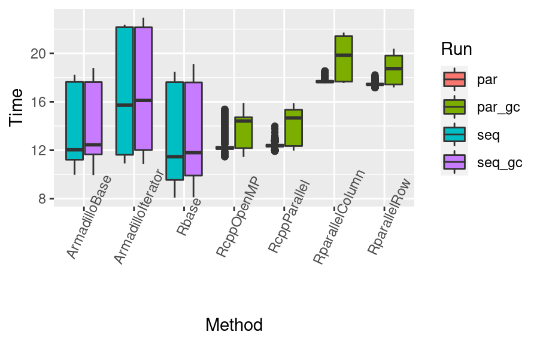

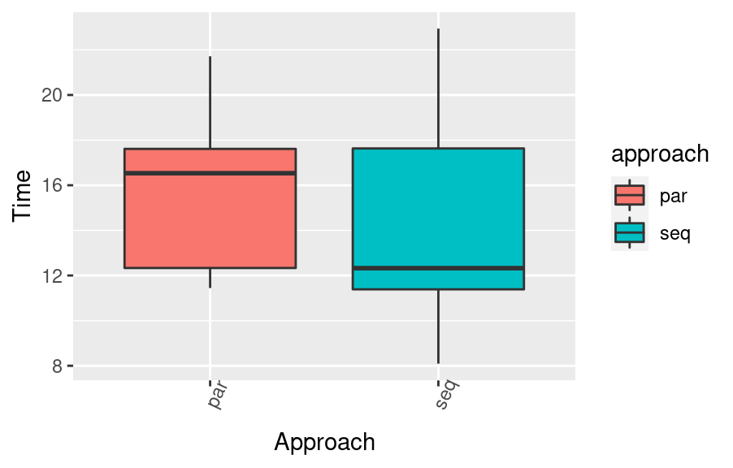

The memory used by R to execute ou simulation is also affected by the version within garbage collector. On the left we have a scatter plot of memory used (above the min) and time required to run. The observations in `seq_gc` and `par_gc` required more memory to run the simulation. In particular, some observations of `seq_gc` used 20% more memory than its version without gc.

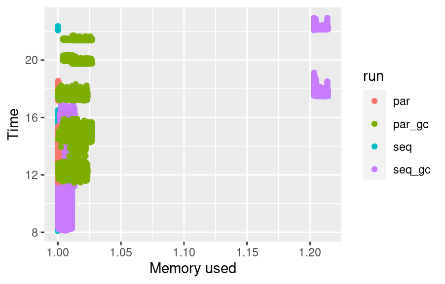

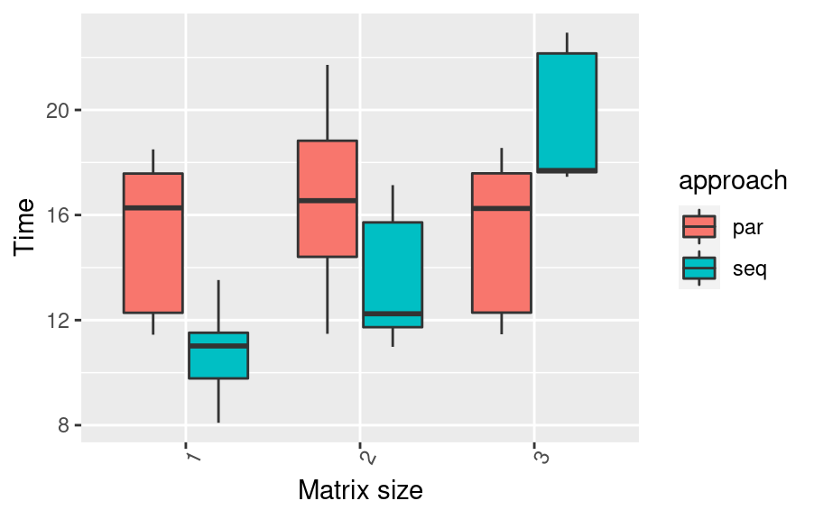

### Boosting Rccp Open MP

The Rcpp Open MP method was the best among the parallel versions of the operation. So we decided to understand which would be the best number of threads to achieve the goal performance. We took the Rbase (median red line) version for baseline comparison purpose. Above we can see a table summarizing the results. The interesting result is that the version without parallel backend had the lowest median, followed by 4 and 2 threads.

| expr | min | median | avg | max | variance |
| --- | --- | --- | --- | --- | --- |
| Rbase | 9.003439 | 9.430439 | 9.437219 | 16.47594 | 0.0661259 |
| RcppOpenMP | 10.960583 | 11.552233 | 11.547314 | 12.64985 | 0.1133718 |
| RcppOpenMP10 | 10.704390 | 12.673852 | 13.057908 | 15.77184 | 1.9564935 |
| RcppOpenMP12 | 11.207120 | 14.090583 | 13.668147 | 15.44366 | 1.4806281 |
| RcppOpenMP2 | 10.870186 | 11.788248 | 11.827120 | 12.63168 | 0.0940119 |
| RcppOpenMP4 | 10.877481 | 11.758656 | 11.874120 | 15.17336 | 0.2456133 |
| RcppOpenMP8 | 10.711926 | 12.111778 | 12.485314 | 15.35840 | 1.4745275 |

Below is a graph to illustrate the data seen in the table.

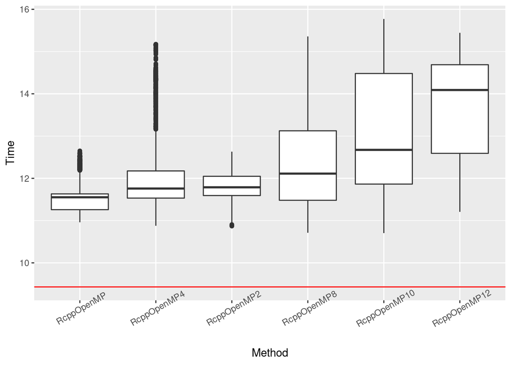